# Homework 3: IRT Models II

Preparation for the Research Seminar Political Data Journalism  
Fall Semester 2024  
Department of Political Science  
University of Zurich

Name

Matrikelnummer

Mirko Bozic

xxxxxxxx

Date

11 November 2024

## Instructions

For this assignment, you need to complete the exercises and submit your solutions in the form of **rendered `.html` documents**. **Full points** will be given only for complete written answers, well-designed figures, and properly formatted tables, not for single snippets of code or printed output from R functions. You need to use informative titles, captions, and labels for every table and figure. You need to use `set.seed(1234)` whenever you need to set a seed to make your analysis reproducible. **Make sure to fully interpret all of the results in written answers!**

Complete the following steps:

1. Open RStudio by double-clicking the Rproject (`.Rproj`) file, then open the Quarto markdown (`.qmd`) file of the exercise in RStudio
2. Replace FIRSTNAME LASTNAME in the YAML header of this document with your own name and `1234567890` with your own Matrikelnummer.
3. For each question, replace `# YOUR CODE` with your own R code, and replace `YOUR ANSWER` with your written answers (note: some questions only require a written answer). **You can add additional R chunks, table and figure captions, citations, footnotes, and cross-references, as needed.**
4. Render the Quarto markdown (`.qmd`) file to a `.html` file by clicking the “Render” button. This will run the entire script from top to bottom in a fresh R session. Make sure that there are no errors in your code. Carefully reading any error messages will help you debugging your code. It is strongly recommend to render the document regularly while working on completing the assignment, in order to ensure that the code works as intended, and that you do not encounter any last minute surprises. **I will only grade fully rendered `.html` files!**
5. Fill out the Declaration of Authorship.
6. **When you are finished with all exercises**, compress all the files in your assignment folder to a `.zip` file (the Quarto markdown files, the HTML files you created, the Data folder, the Rproject.Rproj file, and the Declaration of Authorship).
7. **Submit** the zipped folder before the deadline in the drop box of the course on OLAT.

## Dataset

The basis of this housework are votes in the National Council. Use only final and overall votes. Work with the votes of the year you have been assigned. If you would like to use your own data set, please contact me.

## Load Packages

```r
# Load your packages here
library("conflicted")
library("gt")
library("haven")
library("MASS")
library("plotrix")
library("reshape2")
library("rstan")
library("tidyverse")
library("purrr")
conflicts_prefer(
  dplyr::filter,
  dplyr::select,
  reshape2::smiths,
  rstan::extract,
  stats::lag
)

# Set options for rstan
options(mc.cores = parallelly::availableCores())
rstan_options(auto_write = TRUE)
```

**Set ggplot theme and use colorblind-friendly color palette**

```r
# Set ggplot theme
theme_set(
  theme_minimal() +
    theme(
      plot.title = element_text(face = "bold"),
      plot.title.position = "plot",
      legend.position = "top",
      panel.grid.minor = element_blank()
    )
)

# Use colorblind-friendly color palette
okabe_ito <- unname(palette.colors(palette = "Okabe-Ito")[c(2:8, 1)])
options(ggplot2.continuous.color = okabe_ito)
options(ggplot2.continuous.colour = okabe_ito)
options(ggplot2.continuous.fill = okabe_ito)
options(ggplot2.discrete.color = okabe_ito)
options(ggplot2.discrete.colour = okabe_ito)
options(ggplot2.discrete.fill = okabe_ito)

# Turn off scientific notation
options(scipen = 999)
```

```r
load("all_objects.RData")
```

# Question 1

### Use the dataset you have chosen for all tasks. In the following, use one of the two-dimensional models that we used in the lecture.

## Question 1a

### Pick two MPs which you can fix at -1 and 1. Then choose two votes that you will use for the identifying assumptions. Justify your choice and how these votes are likely to discriminate.

```r
votes <- read_dta("Data Homework 3/NR_0102.dta")
```

```r
votes_ <- votes |>
  mutate(answercode = recode(answercode, "0" = "0", "1" = "1", .default = NA_character_))

# Assign consecutive MP IDs
votes_$mp_id1 <- rep(NA, length(votes_$mp_id))
a <- 0
for (i in unique(votes_$mp_id)) {
  a <- a + 1
  votes_$mp_id1[votes_$mp_id == i] <- a
}

# Assign consecutive Bill IDs
votes_$vote_id1 <- rep(NA, length(votes_$mp_id))
b <- 0
for (i in unique(votes_$vote_id)) {
  b <- b + 1
  votes_$vote_id1[votes_$vote_id == i] <- b
}

# Create data frame with MP information
mp_info <- votes_ |>
  select(mp_id, lastname, firstname, canton, party_abbreviation, mp_id1) |>
  distinct() |> # Remove duplicate rows
  filter(!duplicated(mp_id)) |> # Remove duplicated mp_id
  mutate(
    labels_main_parties = case_when(
      !party_abbreviation %in% c("GPS", "SP", "CVP", "FDP-Liberale", "SVP") ~ "Other",
      .default = party_abbreviation
    ),
    name_for_plotting = paste(firstname, lastname, party_abbreviation, canton)
  ) |>
  arrange(mp_id1)

# Create data frame with bill information
bill_info <- votes_ |>
  select(vote_id, date, bill_title, bill_url, vote_id1) |>
  distinct() |> # Remove duplicate rows
  filter(!duplicated(vote_id)) |> # Remove duplicated vote_id
  arrange(vote_id1)

# Select most useful variables
votes_sel<- votes_ |>
  select(answercode, vote_id, bill_title, bill_url, mp_id, party_abbreviation, lastname, firstname, canton)
```

By taking a look at the data it becomes clear that we are dealing with parliamentarian votes from the lower chamber of the Swiss Parliament, the “Nationalrat” or *National Council*, in the period from the spring session of 2001 to the winter session of 2002. Because we aim to estimate a model based on Bayesian statistical assumptions, we need to choose which two MPs to fix at -1 and +1 on a latent ideological dimension. In Switzerland, as in most liberal democratic polities around the world, we assume these MPs to be on opposing and correct sides of the traditional left-right political spectrum across bills. The traditional left-right dimension has its origins in the very foundation of liberal, multi party parliaments. Using our knowledge of politics and experience of the Swiss political system, we’d like to fix MPs we assume to (almost) never share the same ideal point on said latent dimension. This knowledge, e.g. choice of fixed legislators, carries a set of assumptions into the statistical model of the Swiss National Council ideological composition. In Switzerlands case, one can reasonably argue that an MP of the GPS (“Grüne Partei Schweiz”) distinctly votes towards the left political extreme, while an MP of the SVP (“Schweizerische Volkspartei”) votes towards the right political extreme and that these party members are very unlikely to have identical ideal point posterior distributions. Let’s take the MP’s origin into account and select a GPS MP from an city-canton such as Basel Stadt or Geneva, because urban city societies tend to be left leaning in general. We might choose **Patrice Mugny, GE (GPS**) as our fixed MP at -1. On the other side, we might choose **Christoph Mörgeli, ZH (SVP)** as our fixed MP at +1, who is known to have politicized in a populist far-right political frame. Although this choice of legislators might implicate differences on more than one dimension, simply their allegiance to their respective parties, in the Swiss National Council, might suffice to identify the traditional left-right plane.

```r
selected_mps <- mp_info %>% slice(c(69, 137))
selected_mps %>% gt()
```

| mp_id | lastname | firstname | canton | party_abbreviation | mp_id1 | labels_main_parties | name_for_plotting |
| --- | --- | --- | --- | --- | --- | --- | --- |
| 497 | Mugny | Patrice | GE | GPS | 69 | GPS | Patrice Mugny GPS GE |
| 542 | Mörgeli | Christoph | ZH | SVP | 137 | SVP | Christoph Mörgeli SVP ZH |

```r
gt(bill_info[219, ])
```

| vote_id | date | bill_title | bill_url | vote_id1 |
| --- | --- | --- | --- | --- |
| 46.6-1175 | 2001-03-23 08:52:33 | Schwangerschaftsabbruch. Revision des Strafgesetzbuches | http://www.parlament.ch/d/suche/seiten/geschaefte.aspx?gesch_id=19930434 | 219 |

Bill “Schwangerschaftsabbruch. Revision des Strafgesetzbuchs”, which aims to reform abortion law, is highly likely to mobilize opinions on the **gal-tan** ideological spectrum. This particular bill seeks to liberalize abortion practice further by determining a period in early pregnancy, where women can perform an abortion by their own decision, and clearly define the threshold for abortions in later stages of pregnancy, thus overall giving women more power in abortion decisions. We expect this bill to gain support from legislators on the gal side of the spectrum, e.g. green-alternative-libertarian legislators, who favor individual freedoms over state-supported traditional values expressed on the tan side of the spectrum, e.g. traditional-authoritarian-nationalist values. We do not expect this bill to discriminate along the economic left-right divide, in fact, by taking a look at the Swissvotes (n.d.) website, we see that apart from the Swiss Union’s Association, no other federal economic or trade association cast a vote recommendation for the popular vote on this bill. We want to model the gal side of the gal-tan dimension with positive values, the according $beta$ for this bill would look something like $[0, 15]$.

```r
gt(bill_info[261, ])
```

| vote_id | date | bill_title | bill_url | vote_id1 |
| --- | --- | --- | --- | --- |
| 46.8-1398 | 2001-06-22 08:45:27 | Schuldenbremse | http://www.parlament.ch/d/suche/seiten/geschaefte.aspx?gesch_id=20000060 | 261 |

On the other side, we expect the bill “Schuldenbremse” to mobilize opinions predominantly on the economic left-right dimension. This bill proposes a mechanism for imposing household dept lowering measures, which traditionally is a priority for the economic right, whereas the economic left tends to prefer household spending liberty. The vote on this bill supports these assumptions, as the Green and Socialist parliamentary fractions exclusively voted “No” or abstained from the vote. The official documentation on this bill (Curia Vista n.d.) explicitly mentions a “left-right” debate in the National Council. We don’t expect this bill to discriminate along the tan-gal ideological dimension, our $beta$ would accordingly look something like $[15, 0]$.

## Question 1b

### Estimate a 2D model with all assumptions and check if it has converged (Rhat and with *traceplots*). If it has not converged, you can make other identifying assumptions and run it again. If it still does not work, try a third time. If it still doesn’t work after the third time, just continue with the third model (make sure to mention in your statements that you are based on a *non-converged* model).

```r
nasCH <- which(is.na(votes_$answercode))
votesCH <- as.numeric(votes_$answercode[-nasCH])
N <- length(votesCH)
j <- votes_$mp_id1
j <- j[-nasCH]
k <- votes_$vote_id1
k <- k[-nasCH]
J <- max(j)
K <- max(k)
Dim <- 2
```

```r
CH_data <- list(
  N = N,
  K = K,
  J = J,
  j = j,
  k = k,
  y = votesCH,
  D = Dim,
  l1 = 69,
  l2 = 137,
  b1 = 219,
  b2 = 261,
  mu11 = 0,
  v11 = 1,
  mu12 = 15,
  v12 = 3,
  mu21 = 15,
  v21 = 3,
  mu22 = 0,
  v22 = 1
)


stan_fit2 <- stan(
  file = "Stan Files/Stan2d.stan",
  data = CH_data,
  iter = 8000,
  warmup = 5000,
  chains = 4,
  thin = 5,
  init = "random",
  verbose = FALSE,
  seed = 1234
)
```

```r
starttime2 <- Sys.time()
endtime2 <- Sys.time()
runtime2 <- difftime(endtime2, starttime2, units = "mins")
html("Runtime:", round(runtime2, 2), "minutes")
```

Runtime: 0 minutes

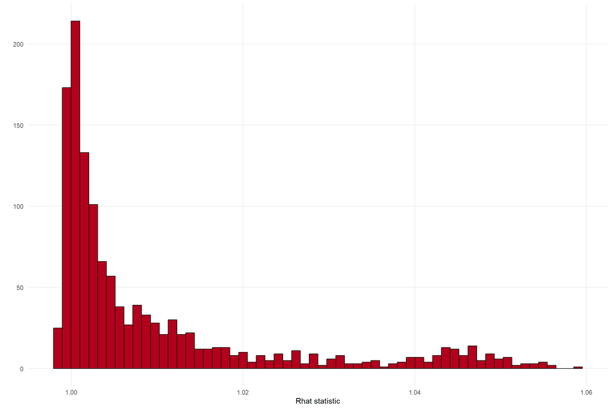

```r
stan_rhat(stan_fit2, bins = 60) + theme_get()
```

The Rhat statistic indicates a good convergence of the posterior chains, as the maximum value is below 1.06. Next we take a look at some traceplots to confirm the convergence result.

Figure 1: trace

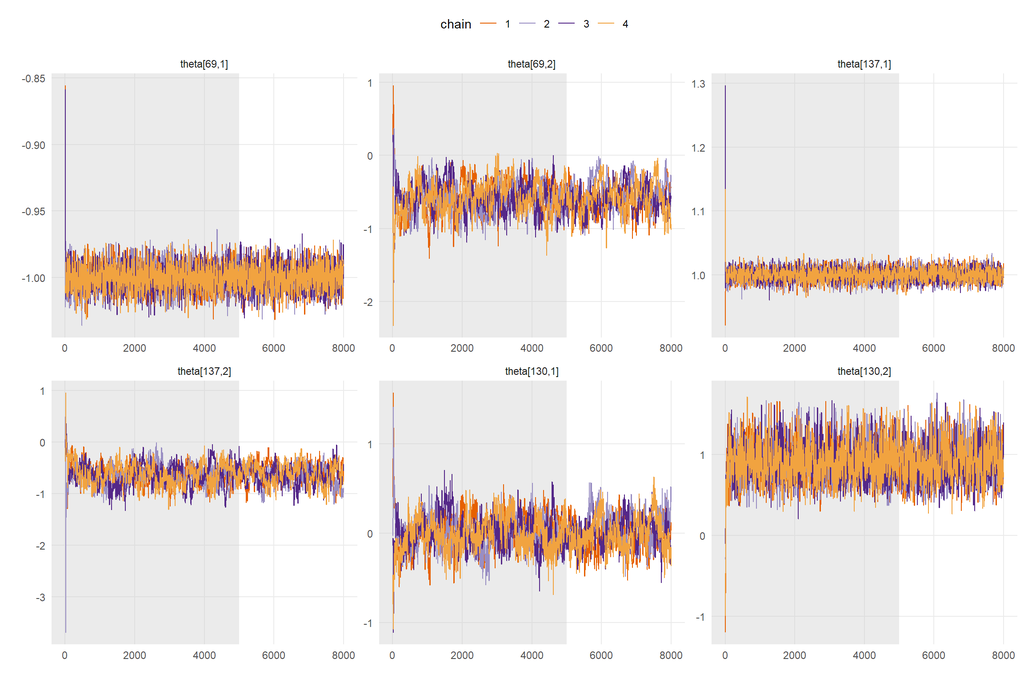

```r
stan_fit2 |>
  stan_trace(
    pars = c("theta[69,1]", "theta[69,2]", "theta[137,1]", "theta[137,2]", "theta[130,1]", "theta[130,2]"),
    inc_warmup = TRUE
  ) +
  theme_get()
```

We observe convergence issues primarily on the second model dimension. The divergence is not huge, as indicated by acceptable Rhat values. We still might try to increase iterations in our stan model, or change the identifying assumptions, e.g. choose new MPs or other bills. I’ll run the new model below.

### Model alternative 1

Our considerations on the National Council concerning its origin and composition still hold true, but this time we might want to choose two MPs ideologically even further apart from each other. When observing the final vote record on bill “Schwangerschaftsabbruch. Revision des Strafgesetzbuchs”, we see that Patrice Mugny, GPS GE and Christoph Mörgeli, SVP ZH, both voted “Yes”. Although we expect this bill only to discriminate along the socio-cultural dimension “gal-tan”, the model might have difficulties to discriminate between these MPs on the first dimension, in case the two dimensions correlate in some way. For our new model we choose the female GPS politician **Anne-Catherine Ménétrey-Savary, GPS VD** for the lower bound restriction, and restrict **Christoph Blocher, SVP ZH** to +1. These legislators voted on opposed sides on both aforementioned bills.

```r
selected_mps2 <- mp_info %>% slice(c(188, 82))
selected_mps2 %>% gt()
```

| mp_id | lastname | firstname | canton | party_abbreviation | mp_id1 | labels_main_parties | name_for_plotting |
| --- | --- | --- | --- | --- | --- | --- | --- |
| 495 | Menétrey-Savary | Anne-Catherine | VD | GPS | 188 | GPS | Anne-Catherine Menétrey-Savary GPS VD |
| 21 | Blocher | Christoph | ZH | SVP | 82 | SVP | Christoph Blocher SVP ZH |

We further stick to the choice of bills for the identifying assumptions, as the bills align well with the dimensions we seek to uncover. But this time, we might set the discrimination values $beta$ to a higher value, e.g. $beta219[0, 20]$ and $beta261[20, 0]$.

```r
selected_bills2 <- bill_info %>% slice(c(219, 261))
selected_bills2 %>% gt()
```

| vote_id | date | bill_title | bill_url | vote_id1 |
| --- | --- | --- | --- | --- |
| 46.6-1175 | 2001-03-23 08:52:33 | Schwangerschaftsabbruch. Revision des Strafgesetzbuches | http://www.parlament.ch/d/suche/seiten/geschaefte.aspx?gesch_id=19930434 | 219 |
| 46.8-1398 | 2001-06-22 08:45:27 | Schuldenbremse | http://www.parlament.ch/d/suche/seiten/geschaefte.aspx?gesch_id=20000060 | 261 |

```r
CH_data2 <- list(
  N = N,
  K = K,
  J = J,
  j = j,
  k = k,
  y = votesCH,
  D = Dim,
  l1 = 188,
  l2 = 82,
  b1 = 219,
  b2 = 261,
  mu11 = 0,
  v11 = 1,
  mu12 = 20,
  v12 = 3,
  mu21 = 20,
  v21 = 3,
  mu22 = 0,
  v22 = 1
)


stan_fit3 <- stan(
  file = "Stan Files/Stan2d.stan",
  data = CH_data2,
  iter = 8000,
  warmup = 5000,
  chains = 4,
  thin = 5,
  init = "random",
  verbose = FALSE,
  seed = 1234
)
```

```r
starttime3 <- Sys.time()
endtime3 <- Sys.time()
runtime3 <- difftime(endtime3, starttime3, units = "mins")
html("Runtime:", round(runtime3, 2), "minutes")
```

Runtime: 0 minutes

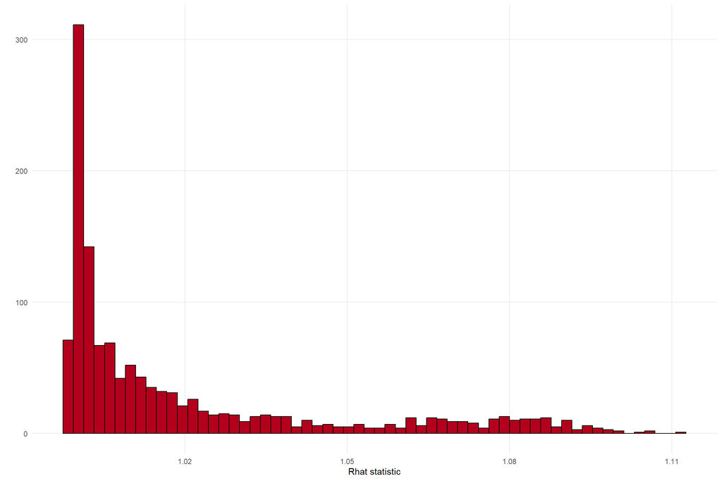

```r
stan_rhat(stan_fit3, bins = 60) + theme_get()
```

The new identifying assumptions actually led to a worse chain convergence, as the maximum Rhat values cross the 1.1 threshold.

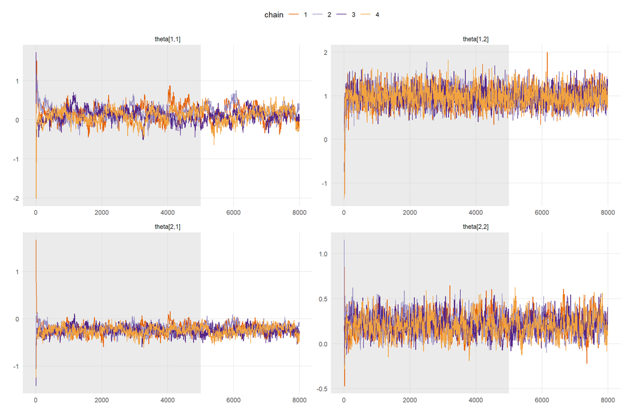

```r
stan_fit3 |>
  stan_trace(
    pars = c("theta[1,1]", "theta[1,2]", "theta[2,1]", "theta[2,2]"),
    inc_warmup = TRUE
  ) +
  theme_get()
```

The selection of traceplots looks similar to the first model “stan_fit2”, though the first model performed better with the same amount of iterations. We’ll thus run the first model again, with higher iterations.

### Model alternative 2

```r
selected_mps3 <- mp_info %>% slice(c(69, 137))
selected_mps3 %>% gt()
```

| mp_id | lastname | firstname | canton | party_abbreviation | mp_id1 | labels_main_parties | name_for_plotting |
| --- | --- | --- | --- | --- | --- | --- | --- |
| 497 | Mugny | Patrice | GE | GPS | 69 | GPS | Patrice Mugny GPS GE |
| 542 | Mörgeli | Christoph | ZH | SVP | 137 | SVP | Christoph Mörgeli SVP ZH |

```r
selected_bills3 <- bill_info %>% slice(c(219, 261))
selected_bills3 %>% gt()
```

| vote_id | date | bill_title | bill_url | vote_id1 |
| --- | --- | --- | --- | --- |
| 46.6-1175 | 2001-03-23 08:52:33 | Schwangerschaftsabbruch. Revision des Strafgesetzbuches | http://www.parlament.ch/d/suche/seiten/geschaefte.aspx?gesch_id=19930434 | 219 |
| 46.8-1398 | 2001-06-22 08:45:27 | Schuldenbremse | http://www.parlament.ch/d/suche/seiten/geschaefte.aspx?gesch_id=20000060 | 261 |

Additionally, we’ll combine the approach from model 1 with model 2, setting the discrimination values $beta$ for the chosen bill to $20$ in the right dimension.

```r
CH_data3 <- list(
  N = N,
  K = K,
  J = J,
  j = j,
  k = k,
  y = votesCH,
  D = Dim,
  l1 = 69,
  l2 = 137,
  b1 = 219,
  b2 = 261,
  mu11 = 0,
  v11 = 1,
  mu12 = 20,
  v12 = 3,
  mu21 = 20,
  v21 = 3,
  mu22 = 0,
  v22 = 1
)

stan_fit4 <- stan(
  file = "Stan Files/Stan2d.stan",
  data = CH_data3,
  iter = 10000,
  warmup = 7000,
  chains = 4,
  thin = 5,
  init = "random",
  verbose = FALSE,
  seed = 1234
)
```

```r
starttime4 <- Sys.time()
endtime4 <- Sys.time()
runtime4 <- difftime(endtime4, starttime4, units = "mins")
html("Runtime:", round(runtime4, 2), "minutes")
```

Runtime: 0 minutes

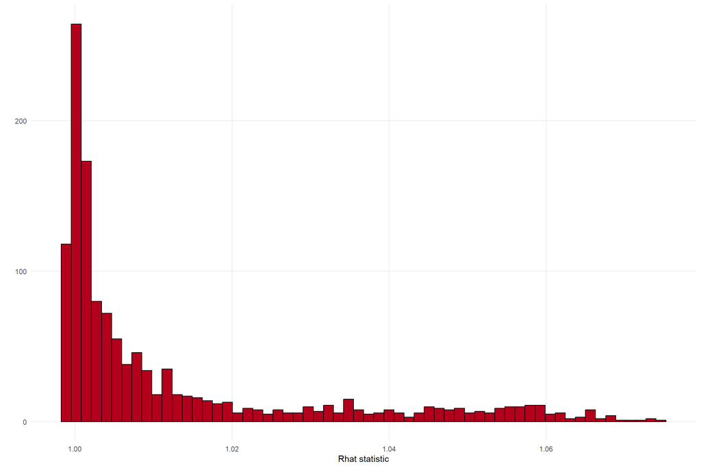

```r
stan_rhat(stan_fit4, bins = 60) + theme_get()
```

Running the model from the first notebook with more iterations and more extreme $beta$ restrictions doesn’t seem to help convergence, quite the opposite. We couldn’t resolve convergence issues, especially on the second dimenson, as is visible below in the traceplots. From here on we’ll work with the first model, as it shows the lowest Rhat values out of the three stan models.

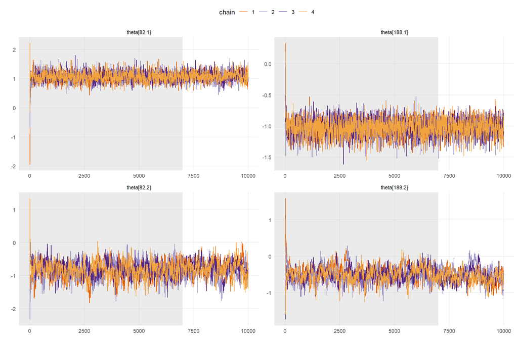

```r
stan_fit4 |>
  stan_trace(
    pars = c("theta[82,1]", "theta[188,1]", "theta[82,2]", "theta[188,2]"),
    inc_warmup = TRUE
  ) +
  theme_get()
```

## Question 1c

### Display your results graphically (without uncertainty). Write your *own code* and represent each parliamentarian with a dot. Use colors to distinguish the parties.

The subsequent model alternatives didn’t provide a substantial improvement in chain convergence over “stan_fit2”, which leads us to continue our analysis with the first model.

```r
df_thetas <- rstan::extract(stan_fit2)$theta |>
  as_tibble() |>
  rename_with(~ paste0("theta", .))
```

```r
theta_means <- df_thetas |>
  summarise(across(everything(), mean, na.rm = TRUE))
```

```r
theta_plot_data <- theta_means |>
  pivot_longer(cols = everything(), names_to = "parameter", values_to = "mean") |>
  separate(parameter, into = c("base", "dimension"), sep = "\\.", convert = TRUE) |>
  pivot_wider(names_from = dimension, values_from = mean, names_prefix = "dim_") |>
  rename(x = dim_1, y = dim_2) |>
  mutate(mp_id1 = row_number())

theta_plot_data <- theta_plot_data |>
  left_join(mp_info %>% select(mp_id1, labels_main_parties), by = "mp_id1")
```

Figure 2: plot2D

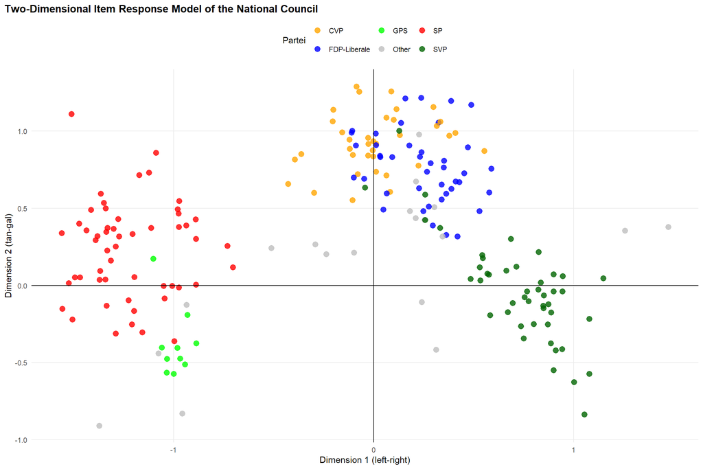

```r
party_colors <- c(
  "GPS" = "green",        # Grüne Partei der Schweiz
  "SP" = "red",         # Sozialdemokratische Partei
  "CVP" = "orange",        # Christlichdemokratische Volkspartei
  "FDP-Liberale" = "blue", # FDP.Die Liberalen
  "SVP" = "darkgreen",        # Schweizerische Volkspartei
  "Other" = "grey"       # Andere Parteien
)
plot_2D <- ggplot(theta_plot_data, aes(x = x, y = y, color = labels_main_parties)) +
  geom_point(size = 3, alpha = 0.8) +
  geom_hline(yintercept = 0, color = "black", size = 0.5) +
  geom_vline(xintercept = 0, color = "black", size = 0.5) +
  labs(
    title = "Two-Dimensional Item Response Model of the National Council",
    x = "Dimension 1 (left-right)",
    y = "Dimension 2 (tan-gal)",
    color = "Partei"
  ) +
  scale_color_manual(values = party_colors) +
  theme_get()
plot_2D
```

One cannot but notice a serious flaw in this graphic: The second dimension, which is supposed to represent the tan-gal ideological spectrum, obviously makes little sense, as the “Green Party Switzerland” is on the traditional-authoritarian side together with the SVP, whereas the CVP, a traditionally catholic-conservative party, finds itself on the gal side of the spectrum. This opens questions about identifying assumptions as well as the underlying latent dimension, as the tan-gal dimension is not just inverted. We could have expected difficulties in identifying the second dimension, as the traceplots in Figure 1 pointed to a bad convergence in the second dimension posterior distribution chains.

# Question 2

### In this task you should work with the estimation results of the above model (1b).

## Question 2a

### Which politician is the most “right” on the first dimension? How sure are you of this statement?

```r
most_right_d1 <- theta_plot_data %>% filter(x == max(x, na.rm = TRUE))
most_right_d1
```

```
# A tibble: 1 × 5
  base         x     y mp_id1 labels_main_parties
  <chr>    <dbl> <dbl>  <dbl> <chr>
1 theta101  1.47 0.380    101 Other
```

```r
gt(mp_info[101, ])
```

| mp_id | lastname | firstname | canton | party_abbreviation | mp_id1 | labels_main_parties | name_for_plotting |
| --- | --- | --- | --- | --- | --- | --- | --- |
| 279 | Bignasca | Giuliano | TI | Lega | 101 | Other | Giuliano Bignasca Lega TI |

Giuliano Bignasca, Lega TI seems to be the most right MP on the left-right dimension, having the highest average $theta$ on the first dimension.

```r
df_thetas |>
  rowwise() |>
  mutate(Bignasca_most_right = case_when(
    `theta101.1` == max(c_across(ends_with(".1"))) ~ "Most right",
    TRUE ~ "Not most right"  # Default case
  )) |>
  pull(Bignasca_most_right) |>
  table()
```

```
    Most right Not most right
          1521            879
```

Out of 2400 observations, Giuliano Bignasca, Lega TI, had the highest value on the first dimension in 1521 cases, thus being the most right-winged MP on the 1st dimension 63.38% of the time. Consequently one could say that Giuliano Bignasca, Lega TI is the most right-winged MP with a probability of 63.38% in our data set.

## Question 2b

### Which politician is most likely to be the most average politician? For this task you can assume that the metrics are the same in both dimensions.

```r
theta_plot_data <- theta_plot_data %>%
  mutate(distance = sqrt(x^2 + y^2))


most_average_mps <- theta_plot_data %>%
  arrange(distance) %>%
  slice_head(n = 5)

table_most_average_mps <- mp_info %>% slice(c(83, 122, 2, 32, 81))
table_most_average_mps %>% gt()
```

| mp_id | lastname | firstname | canton | party_abbreviation | mp_id1 | labels_main_parties | name_for_plotting |
| --- | --- | --- | --- | --- | --- | --- | --- |
| 797 | Donzé | Walter | BE | EVP | 83 | Other | Walter Donzé EVP BE |
| 396 | Waber | Christian | BE | EDU | 122 | Other | Christian Waber EDU BE |
| 449 | Aeschbacher | Ruedi | ZH | EVP | 2 | Other | Ruedi Aeschbacher EVP ZH |
| 515 | Studer | Heiner | AG | EVP | 32 | Other | Heiner Studer EVP AG |
| 419 | Beck | Serge | VD | LPS | 81 | Other | Serge Beck LPS VD |

The most average legislator, e.g. the legislator with an estimated ideal point posterior average closest to $theta[0,0]$ is Walter Donzé, EVP BE. To solidify this claim one needs to take into account confidence intervals from the posterior distribution and observe significant differences to the closest “contenders” for the place of most average legislator across dimensions.

```r
legislator_ids <- 1:206

for (i in legislator_ids) {
  df_thetas <- df_thetas %>%
    mutate(!!paste0("distance_legislator", i) := sqrt(
      .[[paste0("theta", i, ".1")]]^2 + .[[paste0("theta", i, ".2")]]^2
    ))
}
```

```r
distance_cols <- df_thetas %>%
  select(starts_with("distance_legislator"))

results <- distance_cols %>%
  summarise(across(everything(),
                   list(mean = ~ mean(.),
                        lower_ci = ~ quantile(., probs = 0.025),
                        upper_ci = ~ quantile(., probs = 0.975)))) %>%
  pivot_longer(cols = everything(),
               names_to = c("legislator", ".value"),
               names_pattern = "distance_legislator(\\d+)_(.*)") %>%
  mutate(legislator = as.numeric(legislator))

top_10_results <- results %>%
  arrange(mean) %>%
  slice(1:10)

top_10_results <- top_10_results %>%
  left_join(mp_info %>% mutate(legislator = row_number()),
            by = "legislator")
```

Figure 3: euclidian

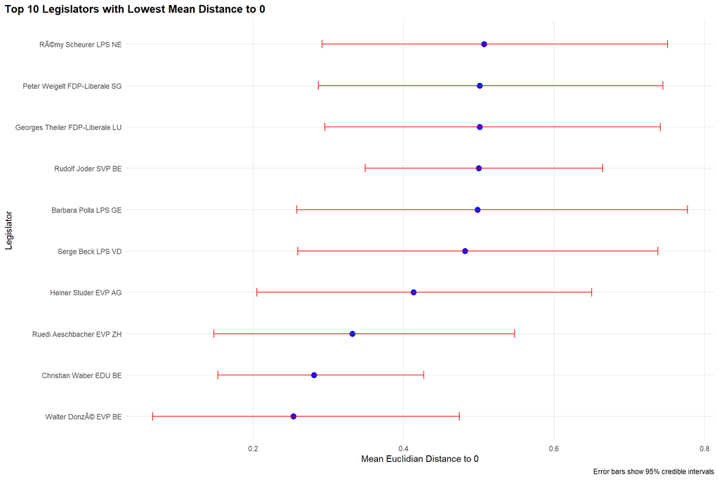

```r
ggplot(top_10_results, aes(x = reorder(name_for_plotting, mean), y = mean)) +
  geom_point(size = 3, color = "blue") +  # Plot mean values
  geom_errorbar(aes(ymin = lower_ci, ymax = upper_ci), width = 0.2, color = "red") +  # Plot error bars
  labs(
    x = "Legislator",
    y = "Mean Euclidian Distance to 0",
    title = "Top 10 Legislators with Lowest Mean Distance to 0",
    caption = "Error bars show 95% credible intervals"
  ) +
  theme_get() +
  coord_flip()
```

```r
smallest_counts <- distance_cols %>%
  rowwise() %>%
  mutate(smallest_legislator = which.min(c_across(everything()))) %>%
  ungroup() %>%
  count(smallest_legislator, name = "count") %>%
  mutate(probability = count / nrow(distance_cols))

# Step 3: Add legislator names
smallest_counts <- smallest_counts %>%
  left_join(mp_info %>% mutate(legislator = row_number()),
            by = c("smallest_legislator" = "legislator")) %>%
  arrange(desc(probability))

# Print top result
gt(smallest_counts)
```

| smallest_legislator | count | probability | mp_id | lastname | firstname | canton | party_abbreviation | mp_id1 | labels_main_parties | name_for_plotting |
| --- | --- | --- | --- | --- | --- | --- | --- | --- | --- | --- |
| 83 | 1058 | 0.4408333333 | 797 | Donzé | Walter | BE | EVP | 83 | Other | Walter Donzé EVP BE |
| 122 | 831 | 0.3462500000 | 396 | Waber | Christian | BE | EDU | 122 | Other | Christian Waber EDU BE |
| 2 | 269 | 0.1120833333 | 449 | Aeschbacher | Ruedi | ZH | EVP | 2 | Other | Ruedi Aeschbacher EVP ZH |
| 32 | 48 | 0.0200000000 | 515 | Studer | Heiner | AG | EVP | 32 | Other | Heiner Studer EVP AG |
| 206 | 34 | 0.0141666667 | 95 | Gonseth | Ruth | BL | GPS | 206 | GPS | Ruth Gonseth GPS BL |
| 8 | 26 | 0.0108333333 | 337 | Lachat | François | JU | CVP | 8 | CVP | François Lachat CVP JU |
| 81 | 18 | 0.0075000000 | 419 | Beck | Serge | VD | LPS | 81 | Other | Serge Beck LPS VD |
| 63 | 17 | 0.0070833333 | 501 | Polla | Barbara | GE | LPS | 63 | Other | Barbara Polla LPS GE |
| 204 | 17 | 0.0070833333 | 74 | Eymann | Christoph | BS | LPS | 204 | Other | Christoph Eymann LPS BS |
| 152 | 14 | 0.0058333333 | 70 | Eggly | Jacques-Simon | GE | LPS | 152 | Other | Jacques-Simon Eggly LPS GE |
| 87 | 12 | 0.0050000000 | 77 | Fehr | Lisbeth | ZH | SVP | 87 | SVP | Lisbeth Fehr SVP ZH |
| 191 | 12 | 0.0050000000 | 325 | Guisan | Yves | VD | FDP-Liberale | 191 | FDP-Liberale | Yves Guisan FDP-Liberale VD |
| 48 | 6 | 0.0025000000 | 83 | Frey | Claude | NE | FDP-Liberale | 48 | FDP-Liberale | Claude Frey FDP-Liberale NE |
| 138 | 5 | 0.0020833333 | 498 | Neirynck | Jacques | VD | CVP | 138 | CVP | Jacques Neirynck CVP VD |
| 192 | 5 | 0.0020833333 | 473 | Hassler | Hansjörg | GR | SVP | 192 | SVP | Hansjörg Hassler SVP GR |
| 17 | 3 | 0.0012500000 | 521 | Wasserfallen | Kurt | BE | FDP-Liberale | 17 | FDP-Liberale | Kurt Wasserfallen FDP-Liberale BE |
| 18 | 3 | 0.0012500000 | 450 | Bader | Elvira | SO | CVP | 18 | CVP | Elvira Bader CVP SO |
| 22 | 3 | 0.0012500000 | 361 | Theiler | Georges | LU | FDP-Liberale | 22 | FDP-Liberale | Georges Theiler FDP-Liberale LU |
| 163 | 3 | 0.0012500000 | 100 | Gysin | Hans Rudolf | BL | FDP-Liberale | 163 | FDP-Liberale | Hans Rudolf Gysin FDP-Liberale BL |
| 169 | 2 | 0.0008333333 | 475 | Hess | Walter | SG | CVP | 169 | CVP | Walter Hess CVP SG |
| 205 | 2 | 0.0008333333 | 314 | Durrer | Adalbert | OW | CVP | 205 | CVP | Adalbert Durrer CVP OW |
| 27 | 1 | 0.0004166667 | 273 | Gadient | Brigitta M. | GR | SVP | 27 | SVP | Brigitta M. Gadient SVP GR |
| 44 | 1 | 0.0004166667 | 193 | Scheurer | Rémy | NE | LPS | 44 | Other | Rémy Scheurer LPS NE |
| 61 | 1 | 0.0004166667 | 483 | Lalive d'Epinay | Maya | SZ | FDP-Liberale | 61 | FDP-Liberale | Maya Lalive d'Epinay FDP-Liberale SZ |
| 75 | 1 | 0.0004166667 | 313 | Dupraz | John | GE | FDP-Liberale | 75 | FDP-Liberale | John Dupraz FDP-Liberale GE |
| 139 | 1 | 0.0004166667 | 368 | Zapfl | Rosmarie | ZH | CVP | 139 | CVP | Rosmarie Zapfl CVP ZH |
| 153 | 1 | 0.0004166667 | 505 | Ruey | Claude | VD | LPS | 153 | Other | Claude Ruey LPS VD |
| 159 | 1 | 0.0004166667 | 474 | Hess | Bernhard | BE | SD | 159 | Other | Bernhard Hess SD BE |
| 160 | 1 | 0.0004166667 | 234 | Wiederkehr | Roland | ZH | LdU | 160 | Other | Roland Wiederkehr LdU ZH |
| 178 | 1 | 0.0004166667 | 366 | Weigelt | Peter | SG | FDP-Liberale | 178 | FDP-Liberale | Peter Weigelt FDP-Liberale SG |
| 185 | 1 | 0.0004166667 | 492 | Mariétan | Fernand | VS | CVP | 185 | CVP | Fernand Mariétan CVP VS |
| 189 | 1 | 0.0004166667 | 490 | Lustenberger | Ruedi | LU | CVP | 189 | CVP | Ruedi Lustenberger CVP LU |
| 203 | 1 | 0.0004166667 | 824 | Salvi | Pierre | VD | SP | 203 | SP | Pierre Salvi SP VD |

Indeed, Walter Donzé, EVP BE has the highest chance to be the most average MP in our data set with 44.1% probability. Christian Waber, EDU BE follows closely with a probability of 34.6% of being the most average MP. The slightly different composition of the above list compared to Figure 3 stems from the fact that Figure 3 used mean values and confidence intervals, while with this approach we counted occurrences of lowest value for distance to $theta[0,0]$, hence implementing a Bayesian approach.

## Question 2c

### Given that your model is based on very specific data, you may well find other basic dimensions. Describe the two dimensions you see in your visualization.

As we can see in Figure 2, there are some issues with the identification of the second dimension, visualized along the y-axis. When discussing the second dimension, one must remember the potential low convergence in the second dimension posterior distribution chains, as visible in Figure 1. Any discussion on identification of said dimension is consequently followed by an assumption of low quality data (too little information, e.g. too many unanimous votes, reiterations of similar votes after deliberation and compromise), and difficulties defining identifiyng assumptions. The wording of specific bills might play a role, as voting “yes” on a specific bill might correspond to voting “no” on another bill, when both bills fundamentally adress the same latent dimension. That said, it is difficult to imagine a credible latent dimension where legislators of the Green Party of Switzerland are closer to members of the SVP than to members of the FDP or even SPS. We can rule out a possible common stance on isolationism (left protects domestic workers, right protects domestic “kin”) for we have seen in my “Homework 2” results that the GPS and SVP are on opposite sides on the globalist-isolationist spectrum. Even though the data in “Homework 2” stems from the 47th legislative period and the data in this file is from the 46th legislative period, drastic ideological changes between two successive parliaments are unlikely. Concerning the second dimension, we might get clarity by visualizing party averages along the second dimension with confidence intervals.

```r
party_summary <- theta_plot_data %>%
  group_by(labels_main_parties) %>%
  summarise(
    mean_x = mean(x, na.rm = TRUE),
    lower_ci_x = quantile(x, probs = 0.025, na.rm = TRUE),
    upper_ci_x = quantile(x, probs = 0.975, na.rm = TRUE),
    mean_y = mean(y, na.rm = TRUE),
    lower_ci_y = quantile(y, probs = 0.025, na.rm = TRUE),
    upper_ci_y = quantile(y, probs = 0.975, na.rm = TRUE)
  ) %>%
  ungroup()
print(party_summary)
```

```
# A tibble: 6 × 7
  labels_main_parties   mean_x lower_ci_x upper_ci_x  mean_y lower_ci_y
  <chr>                  <dbl>      <dbl>      <dbl>   <dbl>      <dbl>
1 CVP                  0.00905     -0.399      0.426  0.927       0.594
2 FDP-Liberale         0.242       -0.108      0.575  0.769       0.328
3 GPS                 -0.994       -1.09      -0.897 -0.380      -0.571
4 Other               -0.0250      -1.24       1.37   0.140      -0.873
5 SP                  -1.22        -1.55      -0.779  0.228      -0.310
6 SVP                  0.731        0.143      1.08  -0.0409     -0.620
# ℹ 1 more variable: upper_ci_y <dbl>
```

Figure 4: partyplotY

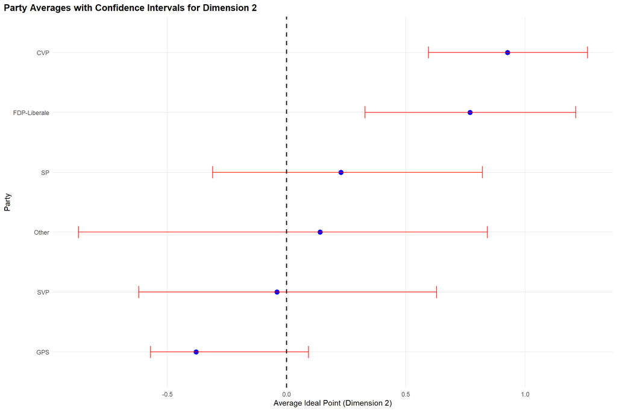

```r
plot_y_means <- ggplot(party_summary, aes(x = reorder(labels_main_parties, mean_y), y = mean_y)) +
  geom_point(size = 3, color = "blue") +
  geom_errorbar(aes(ymin = lower_ci_y, ymax = upper_ci_y), width = 0.2, color = "red") +
  geom_hline(yintercept = 0, linetype = "dashed", color = "black", size = 0.8) +
  labs(
    x = "Party",
    y = "Average Ideal Point (Dimension 2)",
    title = "Party Averages with Confidence Intervals for Dimension 2"
  ) +
  theme_get() +
  coord_flip()
plot_y_means
```

We’d again expect the SP to have more overlapping ideal points with the GPS than with the FDP or SVP. We might get more clarity on this dimension in the next question of this homework assignment. On the other hand, it seems that latent dimension 1 has been properly identified, as the order of the parties along the x-axis in Figure 5 seems reasonable and in accordance with our expectation of the traditional left-right composition of parliament.

Figure 5: partyplotX

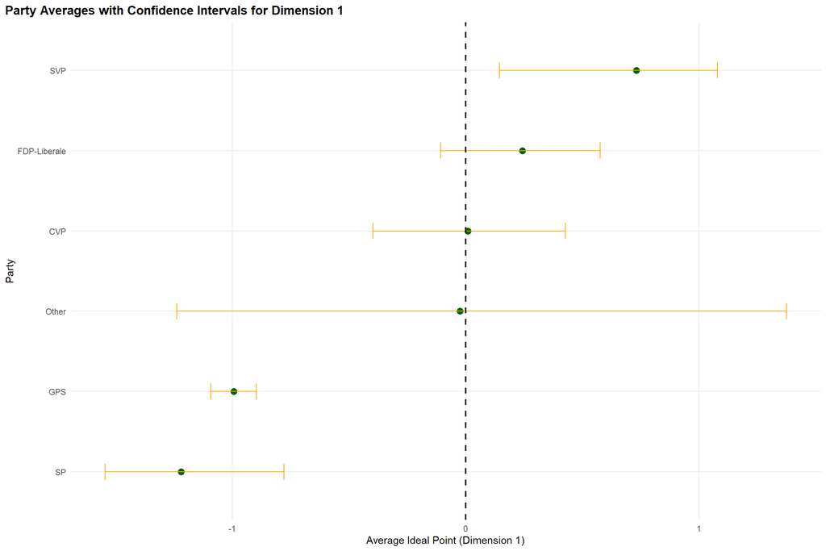

```r
plot_x_means <- ggplot(party_summary, aes(x = reorder(labels_main_parties, mean_x), y = mean_x)) +
  geom_point(size = 3, color = "darkgreen") +  # Change point color to dark green
  geom_errorbar(aes(ymin = lower_ci_x, ymax = upper_ci_x), width = 0.2, color = "orange") +
  geom_hline(yintercept = 0, linetype = "dashed", color = "black", size = 0.8) +
  labs(
    x = "Party",
    y = "Average Ideal Point (Dimension 1)",
    title = "Party Averages with Confidence Intervals for Dimension 1"
  ) +
  theme_get() +
  coord_flip()

# Print the plot
print(plot_x_means)
```

## Question 2d

### Use the discrimination parameter to identify ‘typical’ votes per dimension and verify that your axis description is accurate. Convince me that you identified the dimensions.

“Typical” votes require prior certainty about vote splits in the parliament along expected latent dimensions. Since we have difficulties identifying dimension 2, we’ll start with the highest discrimination parameters for each dimension.

```r
b1 <- grepl("beta", colnames(as.matrix(stan_fit2)))
Betas <- as.matrix(stan_fit2)[, b1]
BB <- apply(Betas, 2, quantile, c(0.025, .5, 0.975))
```

```r
abs(BB[2, ])[order(abs(BB[2, ]), decreasing = TRUE)][1:50]
```

```
beta[158,2] beta[251,1] beta[260,1] beta[137,1] beta[204,1]  beta[68,1]
   21.17161    20.87534    19.88700    19.67084    19.59120    19.58527
 beta[84,1] beta[191,1] beta[151,1] beta[172,2] beta[277,1] beta[156,2]
   18.92428    18.73309    17.91910    17.59519    17.44096    16.95075
beta[120,1] beta[209,1]  beta[19,2] beta[244,1]  beta[25,1] beta[262,1]
   16.76299    16.72086    16.49635    16.42041    16.41596    16.26536
beta[278,1] beta[119,1] beta[246,1] beta[117,1] beta[247,1] beta[243,1]
   15.79719    15.66388    15.63585    15.55898    15.52894    15.42089
beta[184,2] beta[116,1] beta[110,1] beta[242,1] beta[121,1] beta[236,2]
   15.32062    15.31475    15.11853    15.06309    14.92575    14.74015
beta[138,1]  beta[15,2] beta[142,2] beta[117,2]  beta[43,1] beta[212,1]
   14.55919    14.48589    14.46889    14.44570    14.40211    14.38613
 beta[14,2] beta[116,2]  beta[28,1] beta[261,1] beta[274,1]  beta[62,1]
   14.25361    14.08359    13.97576    13.92054    13.79044    13.69962
beta[197,1] beta[256,1] beta[100,2] beta[119,2] beta[258,1] beta[245,1]
   13.52587    13.39052    13.38222    13.37150    13.24090    13.16441
beta[230,1] beta[183,2]
   12.98707    12.97919
```

```r
# 2nd dimension
gt(bill_info[c(158, 172, 156, 19, 184, 236, 15, 142, 117, 14, 116, 100, 119, 183), ])
```

| vote_id | date | bill_title | bill_url | vote_id1 |
| --- | --- | --- | --- | --- |
| 46.15-2890 | 2002-10-04 09:33:55 | Armeereform XXI und Revision Militärgesetzgebung | http://www.parlament.ch/d/suche/seiten/geschaefte.aspx?gesch_id=20010065 | 158 |
| 46.16-3041 | 2002-11-28 11:59:41 | Voranschlag 2003 | http://www.parlament.ch/d/suche/seiten/geschaefte.aspx?gesch_id=20020055 | 172 |
| 46.15-2888 | 2002-10-04 09:32:31 | Armeereform XXI und Revision Militärgesetzgebung | http://www.parlament.ch/d/suche/seiten/geschaefte.aspx?gesch_id=20010065 | 156 |
| 46.11-1790 | 2001-12-05 12:59:30 | Schweizer Beteiligung an der KFOR. Fortführung des Swisscoy-Einsatzes | http://www.parlament.ch/d/suche/seiten/geschaefte.aspx?gesch_id=20010055 | 19 |
| 46.16-3090 | 2002-12-02 20:08:48 | Rüstungsprogramm 2002 | http://www.parlament.ch/d/suche/seiten/geschaefte.aspx?gesch_id=20020053 | 184 |
| 46.8-1315 | 2001-06-13 10:58:38 | Staatsrechnung 2000 | http://www.parlament.ch/d/suche/seiten/geschaefte.aspx?gesch_id=20010010 | 236 |
| 46.11-1778 | 2001-12-05 10:36:22 | Voranschlag 2001. Nachtrag II | http://www.parlament.ch/d/suche/seiten/geschaefte.aspx?gesch_id=20010047 | 15 |
| 46.15-2738 | 2002-09-25 10:21:07 | Militärische Immobilien 2003 | http://www.parlament.ch/d/suche/seiten/geschaefte.aspx?gesch_id=20020045 | 142 |
| 46.15-2574 | 2002-09-16 17:12:45 | Bürgerrechtsregelung. Revision | http://www.parlament.ch/d/suche/seiten/geschaefte.aspx?gesch_id=20010076 | 117 |
| 46.11-1775 | 2001-12-05 10:29:11 | Voranschlag 2002 | http://www.parlament.ch/d/suche/seiten/geschaefte.aspx?gesch_id=20010046 | 14 |
| 46.15-2561 | 2002-09-16 15:58:36 | Bürgerrechtsregelung. Revision | http://www.parlament.ch/d/suche/seiten/geschaefte.aspx?gesch_id=20010076 | 116 |
| 46.14-2396 | 2002-06-19 10:48:40 | Armeereform XXI und Revision Militärgesetzgebung | http://www.parlament.ch/d/suche/seiten/geschaefte.aspx?gesch_id=20010065 | 100 |
| 46.15-2582 | 2002-09-16 18:03:36 | Bürgerrechtsregelung. Revision | http://www.parlament.ch/d/suche/seiten/geschaefte.aspx?gesch_id=20010076 | 119 |
| 46.16-3088 | 2002-12-02 20:06:26 | Rüstungsprogramm 2002 | http://www.parlament.ch/d/suche/seiten/geschaefte.aspx?gesch_id=20020053 | 183 |

```r
# 1st dimension
gt(bill_info[c(251, 137, 204, 68, 84, 191, 151), ])
```

| vote_id | date | bill_title | bill_url | vote_id1 |
| --- | --- | --- | --- | --- |
| 46.8-1388 | 2001-06-22 08:29:16 | . Volksinitiative | http://www.parlament.ch/d/suche/seiten/geschaefte.aspx?gesch_id=19980029 | 251 |
| 46.15-2701 | 2002-09-23 21:50:49 | . Volksinitiativen und Kernenergiegesetz | http://www.parlament.ch/d/suche/seiten/geschaefte.aspx?gesch_id=20010022 | 137 |
| 46.16-3259 | 2002-12-13 10:15:44 | . Volksinitiativen und Kernenergiegesetz | http://www.parlament.ch/d/suche/seiten/geschaefte.aspx?gesch_id=20010022 | 204 |
| 46.12-2137 | 2002-03-20 16:05:22 | Beschwerderecht gegen diskriminierende Einbürgerungsentscheide | http://www.parlament.ch/d/suche/seiten/geschaefte.aspx?gesch_id=20010455 | 68 |
| 46.13-2281 | 2002-04-17 10:02:33 | Anstossfinanzierung für familienergänzende Betreuungsplätze | http://www.parlament.ch/d/suche/seiten/geschaefte.aspx?gesch_id=20000403 | 84 |
| 46.16-3139 | 2002-12-05 11:13:24 | (Gesundheitsinitiative). Volksinitiative | http://www.parlament.ch/d/suche/seiten/geschaefte.aspx?gesch_id=20000046 | 191 |
| 46.15-2883 | 2002-10-04 09:21:38 | Anstossfinanzierung für familienergänzende Betreuungsplätze | http://www.parlament.ch/d/suche/seiten/geschaefte.aspx?gesch_id=20000403 | 151 |

```r
quarto::quarto_version()
```

```
[1] '1.8.24'
```

**WarningNotebook Runtime**

The whole notebook took 1.2 minutes to run

## References

Curia Vista. n.d. “00.060 | Schuldenbremse | Geschäft | Das Schweizer Parlament.” Accessed November 9, 2024. https://www.parlament.ch/de/ratsbetrieb/suche-curia-vista/geschaeft?AffairId=20000060.

Swissvotes. n.d. “Fristenregelung (Schwangerschaftsabbruch).” Swissvotes – die Datenbank der eidgenössischen Volksabstimmungen. Année Politique Suisse, Universität Bern. Accessed November 9, 2024. https://swissvotes.ch/vote/487.00.